# Analiza składu jeziora

### 9.5 Wykres regresji wielomianowej dla ITS

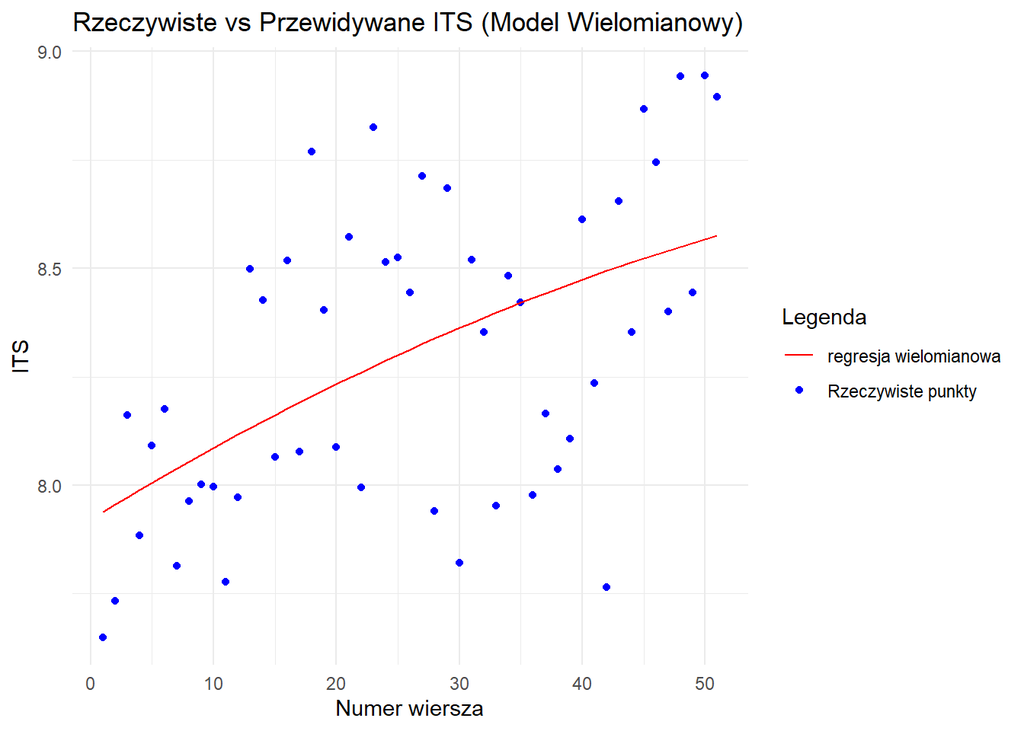

```r
ggplot(data = dane, aes(x = row_number)) +
  geom_point(aes(y = ITS, color = "Rzeczywiste punkty")) +  # Rzeczywiste wartości ITS
  geom_line(aes(y = predicted_poly, color = "regresja wielomianowa")) +  # Linia regresji
  scale_color_manual(name = "Legenda",
                     values = c("Rzeczywiste punkty" = "blue", "regresja wielomianowa" = "red")) +
  labs(title = "Rzeczywiste vs Przewidywane ITS (Model Wielomianowy)",
       x = "Numer wiersza",
       y = "ITS") +
  theme_minimal() +
  theme(legend.position = "right")  # Ustawienie pozycji legendy na prawo
```

### 9.6 Model regresji liniowej dla ITS i Chla

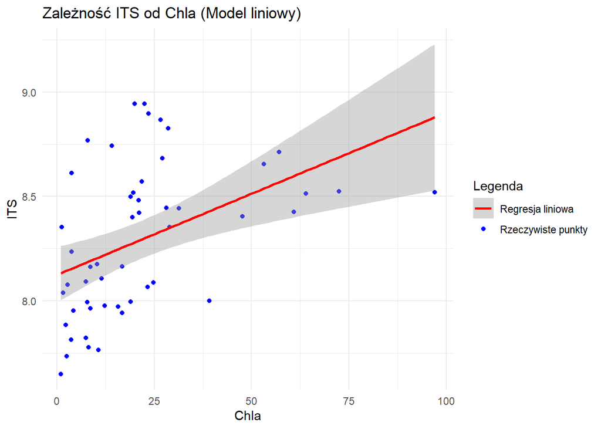

```r
#regresja w zależności od zmiennej chla
ggplot(data = dane, aes(x = chla, y = ITS)) +
  geom_point(aes(color = 'Rzeczywiste punkty')) +  # Rzeczywiste wartości ITS
  geom_smooth(method = "lm", aes(color = "Regresja liniowa")) +  # Linia regresji
  scale_color_manual(name = "Legenda",
                     values = c("Rzeczywiste punkty" = "blue", "Regresja liniowa" = "red")) +
  labs(title = "Zależność ITS od Chla (Model liniowy)",
       x = "Chla",
       y = "ITS") +
  theme_minimal() +
  theme(legend.position = "right")
```

### 9.7 Model regresji wielomianowej dla ITS i Chla

#Dopasowanie modelu wielomianowego drugiego stopnia dla zmiennej Chla

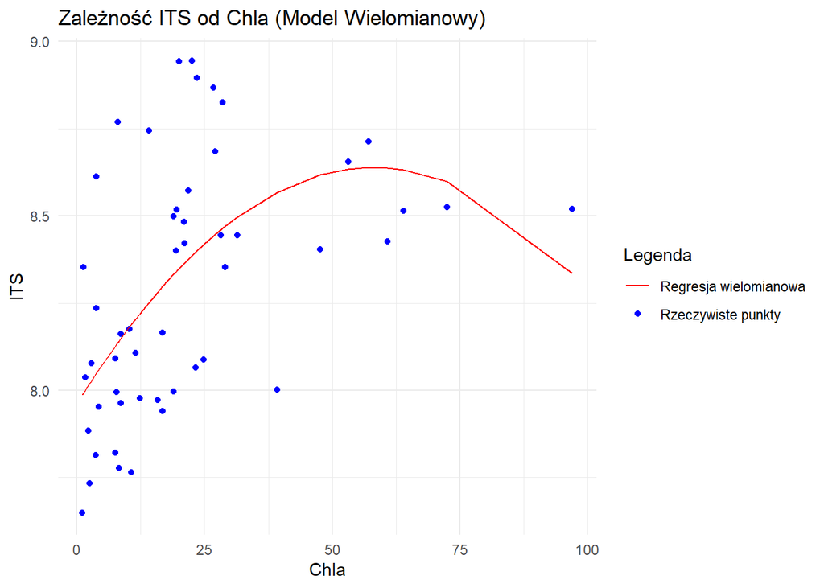

```r
model_poly_chla <- lm(ITS ~ poly(chla, 2), data = dane)

#Przewidywanie wartości na podstawie modelu wielomianowego
dane$predicted_poly_chla <- predict(model_poly_chla, newdata = dane)

#Tworzenie wykresu z legendą
ggplot(data = dane, aes(x = chla)) +
  geom_point(aes(y = ITS, color = "Rzeczywiste punkty")) +  # Rzeczywiste wartości ITS
  geom_line(aes(y = predicted_poly_chla, color = "Regresja wielomianowa")) +  # Linia regresji wielomianowej
  scale_color_manual(name = "Legenda",
                     values = c("Rzeczywiste punkty" = "blue", "Regresja wielomianowa" = "red")) +
  labs(title = "Zależność ITS od Chla (Model Wielomianowy)",
       x = "Chla",
       y = "ITS") +
  theme_minimal() +
  theme(legend.position = "right")  # Ustawienie pozycji legendy na prawo
```

## 10. Optymalizacja modelu dla ITS

### 10.1 Kryterium Informacyjne Akaikego (AIC).

```r
mi2=stepAIC(lm_model)
```

```
Start:  AIC=-3505.16
ITS ~ nas + ph + przew + namon + temp + bar
```

```
        Df Sum of Sq     RSS     AIC
- bar    1   0.00000 0.00000 -3507.1
- namon  1   0.00000 0.00000 -3507.0
- temp   1   0.00000 0.00000 -3506.6
- przew  1   0.00000 0.00000 -3506.6
<none>               0.00000 -3505.2
- nas    1   0.45288 0.45288  -228.9
- ph     1   2.92158 2.92158  -133.8

Step:  AIC=-3507.14
ITS ~ nas + ph + przew + namon + temp
```

```
        Df Sum of Sq    RSS     AIC
- namon  1    0.0000 0.0000 -3508.9
- temp   1    0.0000 0.0000 -3508.6
- przew  1    0.0000 0.0000 -3508.6
<none>               0.0000 -3507.1
- nas    1    0.4536 0.4536  -230.8
- ph     1    2.9235 2.9235  -135.8

Step:  AIC=-3508.94
ITS ~ nas + ph + przew + temp
```

```
        Df Sum of Sq    RSS     AIC
- temp   1    0.0000 0.0000 -3510.3
- przew  1    0.0000 0.0000 -3510.1
<none>               0.0000 -3508.9
- nas    1    0.4874 0.4874  -229.2
- ph     1    3.2407 3.2407  -132.6

Step:  AIC=-3510.28
ITS ~ nas + ph + przew
```

```
        Df Sum of Sq    RSS     AIC
- przew  1    0.0000 0.0000 -3511.4
<none>               0.0000 -3510.3
- nas    1    0.4919 0.4919  -230.7
- ph     1    3.4557 3.4557  -131.3

Step:  AIC=-3511.4
ITS ~ nas + ph
```

```
       Df Sum of Sq    RSS     AIC
<none>              0.0000 -3511.4
- nas   1    0.5833 0.5833  -224.0
- ph    1    3.8082 3.8082  -128.3
```

- AIC spada (np. z -3505.16 do -3511.4), co wskazuje na poprawę modelu przy redukcji zmiennych.
- Przy idealnym dopasowaniu (RSS = 0) znaczenie AIC staje się mniej istotne, ponieważ nie odzwierciedla ono realnej zdolności modelu do generalizacji.

### 10.2 Kombninacje zmiennych

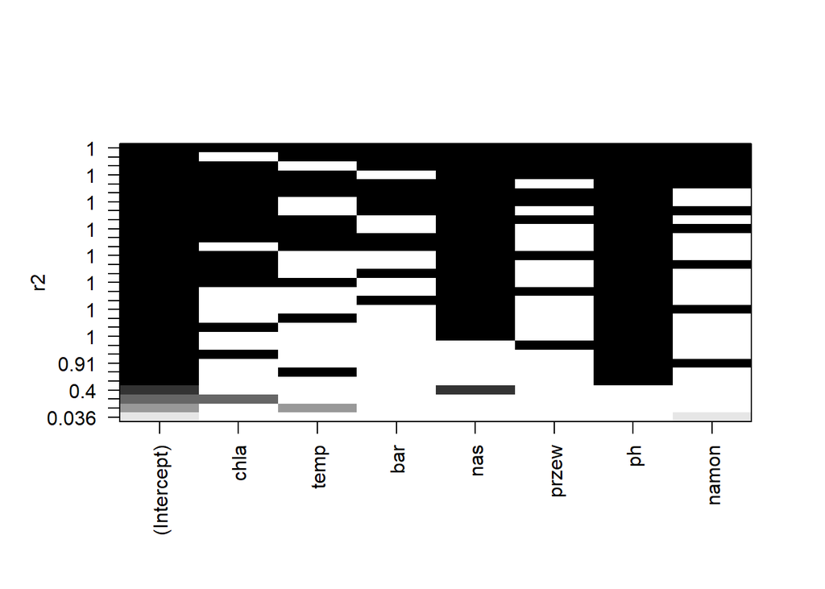

```r
mi3=regsubsets(ITS~.,data=dane[,1:8],nbest=5)
plot(mi3,scale="r2")
```

- Czarne bloki wskazują na obecność danej zmiennej w danym modelu.
- Zmienne, takie jak nas i ph pojawiają się w wielu modelach, co sugeruje ich istotny wpływ na zmienną zależną ITS.
- Niektóre zmienne (np. chla, temp, bar) są mniej istotne, ponieważ pojawiają się w mniejszej liczbie modeli.

### 10.3 Drzewo decyzyjne

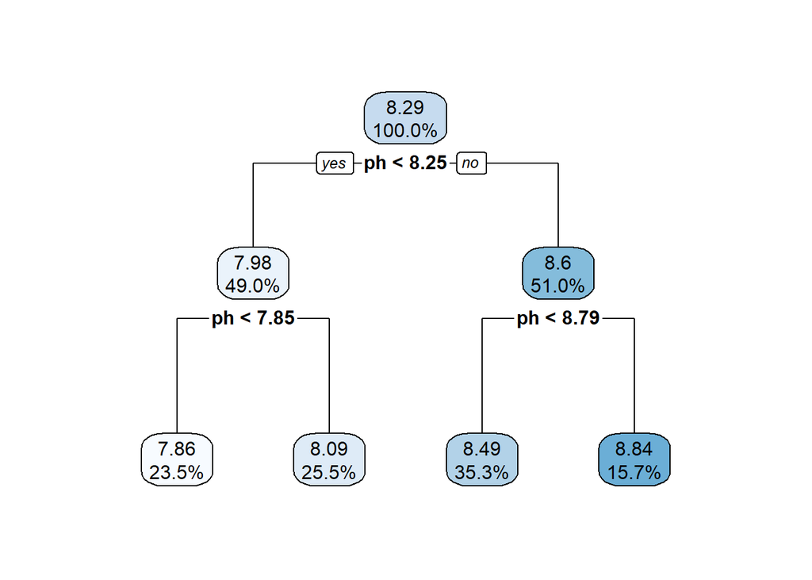

```r
mi4 <- rpart(ITS~.,data=dane[1:8],
                 na.action = na.rpart)
rpart.plot(mi4, digits = 3)
```

- Zmienna ph jest kluczowym czynnikiem wpływającym na wartość ITS.
- Wartość ITS wzrasta wraz z wyższymi wartościami ph
- Najniższe wartości ITS (7.86) występują dla ph < 7.85.
- Najwyższe wartości ITS (8.84) pojawiają się, gdy ph >= 8.79

### 10.4 Model caret - rpart

```r
Control_its <- trainControl(method = "cv", number = 10, verboseIter = T)

# Wersja pierwsza pruning późny - rpart
mi5 <- caret::train(ITS~.,
                       data=dane[,1:8],
                       method = "rpart",
                       metric = 'MAE', # RMSE
                       trControl = Control_its,
                       na.action = na.rpart,
                       tuneLength = 15 # random search, ale po jednym czynniku
)
# Wyniki:
mi5
```

```
CART

51 samples
 7 predictor

No pre-processing
Resampling: Cross-Validated (10 fold)
Summary of sample sizes: 46, 45, 46, 46, 46, 46, ...
Resampling results across tuning parameters:

  cp         RMSE       Rsquared   MAE
  0.0000000  0.1153678  0.9030034  0.09871252
  0.0552304  0.1340513  0.8822506  0.11095920
  0.1104608  0.1610333  0.8426127  0.13226744
  0.1656912  0.1684269  0.8345890  0.14191010
  0.2209216  0.1684269  0.8345890  0.14191010
  0.2761520  0.1684269  0.8345890  0.14191010
  0.3313824  0.1684269  0.8345890  0.14191010
  0.3866128  0.1684269  0.8345890  0.14191010
  0.4418432  0.1684269  0.8345890  0.14191010
  0.4970736  0.1684269  0.8345890  0.14191010
  0.5523040  0.1684269  0.8345890  0.14191010
  0.6075344  0.1684269  0.8345890  0.14191010
  0.6627648  0.1684269  0.8345890  0.14191010
  0.7179952  0.1684269  0.8345890  0.14191010
  0.7732256  0.2752405  0.8157867  0.24559215

MAE was used to select the optimal model using the smallest value.
The final value used for the model was cp = 0.
```

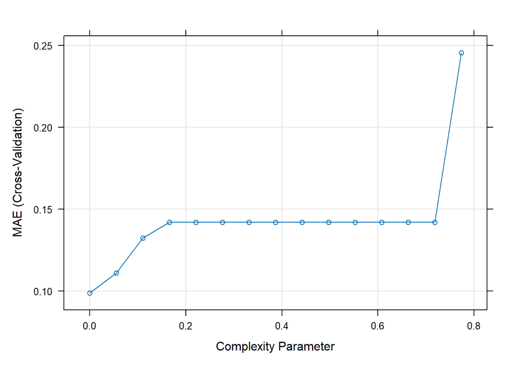

```r
plot(mi5)
```

```r
#CP - parametr złożoności modelu
#MAE - średni błąd bezwzględny (większy -> model mniej dokładny)
```

- Model z parametrem cp = 0 daje najlepsze wyniki, z bardzo niskim błędem MAE i wysokim R², co oznacza, że dobrze odwzorowuje zależności w danych.
- Zwiększanie wartości cp prowadzi do zbyt mocnego przycinania drzewa, co powoduje spadek dokładności modelu (zwiększenie MAE, spadek R²)
- Od cp ok. 0.72 MAE zaczyna gwałtownie rosnąć

### 10.5 Model caret - bagEarth

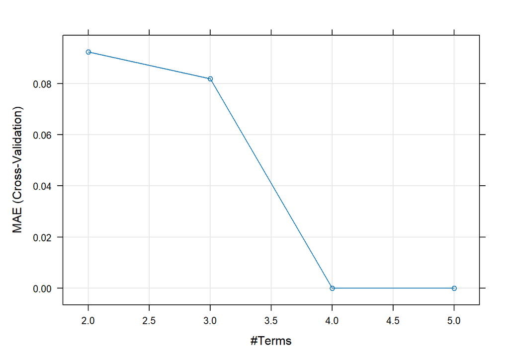

```r
Control <- trainControl(method = "cv", number = 10, verboseIter = T)
mi7 <- caret::train(ITS~.,
                              data=dane[1:8],
                              method = "bagEarth",
                              metric = 'MAE',
                              trControl = Control,
                              na.action = na.omit,
                              tuneLength = 15
)
plot(mi7)
```

```r
#terms -  złożoność modelu w kontekście liczby zmiennych uwzględnionych w modelu.
```

- MAE spada wraz ze wzrostem liczby zmiennych, osiągając stabilizację przy #Terms = 4.
- Dodanie większej liczby zmiennych (przy #Terms > 4) nie poprawia dokładności modelu, co może oznaczać wystarczające dopasowanie już dla 4 Terms
- Wartość MAE spada wraz z pierwszymi dodanymi zmiennymi, co sugeruje, że kluczowe cechy danych są dobrze uchwycone przez model